# IE48B HW#1

M.Burak GÜR

05 11 2021

First start with importing 3D accelerometer data from the file.

```r
library(data.table)
library(ggplot2)
library(scatterplot3d)

current_folder <- getwd()

datasetX <- 'uWaveGestureLibrary_X_TRAIN'
datasetY <- 'uWaveGestureLibrary_Y_TRAIN'
datasetZ <- 'uWaveGestureLibrary_Z_TRAIN'


train_data_pathX=sprintf('uWaveGestureLibrary_X_TRAIN',current_folder,datasetX,datasetX)
train_data_pathY=sprintf('uWaveGestureLibrary_Y_TRAIN',current_folder,datasetY,datasetY)
train_data_pathZ=sprintf('uWaveGestureLibrary_Z_TRAIN',current_folder,datasetZ,datasetZ)

train_dataX=fread(train_data_pathX)
train_dataY=fread(train_data_pathY)
train_dataZ=fread(train_data_pathZ)
```

Instructions says that first values are class information. To clear that, name “V1” was changed into “class”, and data frame was ordered based on class.

```r
setnames(train_dataX,'V1','class')
setnames(train_dataY,'V1','class')
setnames(train_dataZ,'V1','class')

train_dataX=train_dataX[order(class)]
train_dataY=train_dataY[order(class)]
train_dataZ=train_dataZ[order(class)]
```

Calculating velocity vectors by cumulative sum of accelaration.

```r
train_dataX[, names(train_dataX[,-1]) := Reduce(`+`, train_dataX[,-1], accumulate = TRUE)]
train_dataY[, names(train_dataY[,-1]) := Reduce(`+`, train_dataY[,-1], accumulate = TRUE)]
train_dataZ[, names(train_dataZ[,-1]) := Reduce(`+`, train_dataZ[,-1], accumulate = TRUE)]
```

Assigning IDs for each observations and then converting data into long form to plot easily. Before merging data, changing “value” names to its cartesian coordinates to prevent confusion.

```r
train_dataX[,class:=as.character(class)]
train_dataX[,id:=1:.N]
long_trainX=melt(train_dataX,id.vars=c('id','class'))
setnames(long_trainX, 'value', 'valueX')

train_dataY[,class:=as.character(class)]
train_dataY[,id:=1:.N]
long_trainY=melt(train_dataY,id.vars=c('id','class'))
setnames(long_trainY, 'value', 'valueY')

train_dataZ[,class:=as.character(class)]
train_dataZ[,id:=1:.N]
long_trainZ=melt(train_dataZ,id.vars=c('id','class'))
setnames(long_trainZ, 'value', 'valueZ')
```

Binding the value data into a dataframe.

```r
whole_data <- cbind(long_trainX, long_trainY[,'valueY'])
whole_data <- cbind(whole_data, long_trainZ[,'valueZ'])


whole_data[,time:=as.numeric(gsub("\\D", "", variable))-1]

head(whole_data)
```

```
##    id class variable     valueX     valueY     valueZ time
## 1:  1     1       V2 -0.7914472 -1.9599838 -0.2490781    1
## 2:  2     1       V2 -0.4496024 -1.9712004 -1.2897498    1
## 3:  3     1       V2 -0.1874689 -1.2364488 -0.8108461    1
## 4:  4     1       V2  0.3014817 -1.4935131 -1.1472344    1
## 5:  5     1       V2  0.1632022 -0.6158814 -1.3271478    1
## 6:  6     1       V2 -0.9319900 -1.6753297 -1.8033172    1
```

Remove variable column because it is unnecessary.Then order dataframe by id and time.

```r
whole_data=whole_data[,list(id,class,time,valueX,valueY,valueZ)]
whole_data=whole_data[order(id,time)]

head(whole_data)
```

```
##    id class time     valueX     valueY     valueZ
## 1:  1     1    1 -0.7914472  -1.959984 -0.2490781
## 2:  1     1    2 -1.5828944  -3.919968 -0.4981562
## 3:  1     1    3 -2.3787671  -5.876568 -0.7495951
## 4:  1     1    4 -3.1888321  -7.822319 -1.0086052
## 5:  1     1    5 -4.0380621  -9.738128 -1.2885085
## 6:  1     1    6 -4.9415269 -11.612474 -1.5973444
```

Choosing randomly observations from each class and binding together to visualize 3D graphs and data representations.

```r
class1 = whole_data[class== 1 & id==1, ]
class2 = whole_data[class== 2 & id==131, ]
class3 = whole_data[class== 3 & id==270, ]
class4 = whole_data[class== 4 & id==414, ]
class5 = whole_data[class== 5 & id==509, ]
class6 = whole_data[class== 6 & id==614, ]
class7 = whole_data[class== 7 & id==695, ]
class8 = whole_data[class== 8 & id==836, ]
gesture = rbind(class1,class2,class3,class4,class5,class6,class7,class8)
```

Scatter 3D plot to resemble one gesture from class 1.

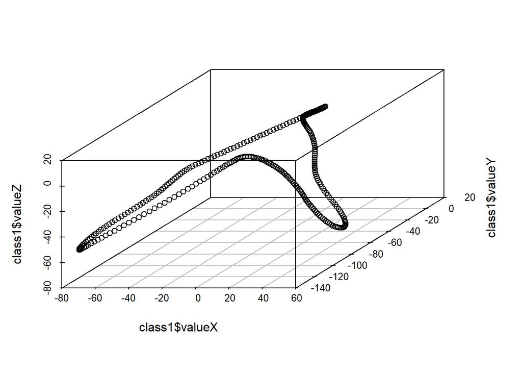

```r
scatterplot3d(x=class1$valueX, y=class1$valueY, z=class1$valueZ )
```

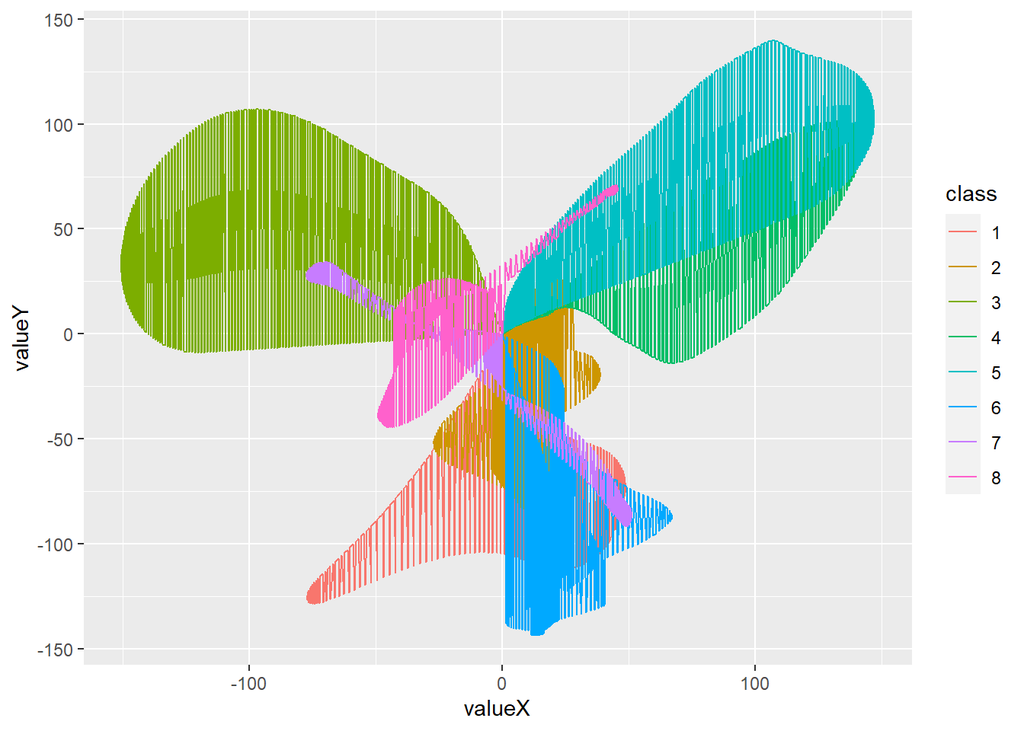

```r
ggplot(gesture, aes(x=valueX, y=valueY, color=class)) + geom_line()
```

BoxPlot Represantations

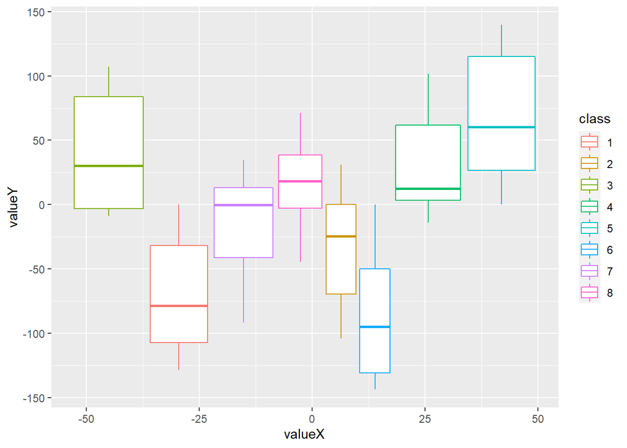

```r
ggplot(gesture, aes(x=valueX, y=valueY, color=class)) +
  geom_boxplot()
```

Represent each series with the interval means. For ValueX

```r
whole_data[,interval_id:=cut(time,2, ordered_result=T),by=list(id)]
str(whole_data)
```

```
## Classes 'data.table' and 'data.frame':   282240 obs. of  7 variables:
##  $ id         : int  1 1 1 1 1 1 1 1 1 1 ...
##  $ class      : chr  "1" "1" "1" "1" ...
##  $ time       : num  1 2 3 4 5 6 7 8 9 10 ...
##  $ valueX     : num  -0.791 -1.583 -2.379 -3.189 -4.038 ...
##  $ valueY     : num  -1.96 -3.92 -5.88 -7.82 -9.74 ...
##  $ valueZ     : num  -0.249 -0.498 -0.75 -1.009 -1.289 ...
##  $ interval_id: Ord.factor w/ 2 levels "(0.686,158]"<..: 1 1 1 1 1 1 1 1 1 1 ...
##  - attr(*, ".internal.selfref")=<externalptr>
```

```r
whole_data[,interval_id:=as.numeric(interval_id)]


stats=whole_data[,list(mean=mean(valueX),median=median(valueX),stdev=sd(valueX)),by=list(class,id,interval_id)]
head(stats)
```

```
##    class id interval_id       mean     median     stdev
## 1:     1  1           1 -33.347640 -35.397850 30.411249
## 2:     1  1           2  21.586584  20.570731 19.384054
## 3:     1  2           1  -4.735015 -11.464862 22.511835
## 4:     1  2           2  64.507174  68.081083 35.403247
## 5:     1  3           1  -1.657602  -2.408139  6.470774
## 6:     1  3           2  30.968987  24.450285 32.972893
```

```r
interval_stats=dcast(stats,id+class~paste0('int_',interval_id),value.var='mean')
head(interval_stats)
```

```
##    id class      int_1    int_2
## 1:  1     1 -33.347640 21.58658
## 2:  2     1  -4.735015 64.50717
## 3:  3     1  -1.657602 30.96899
## 4:  4     1  24.475629 24.19247
## 5:  5     1 -14.671292 26.62806
## 6:  6     1 -54.492657 15.95245
```

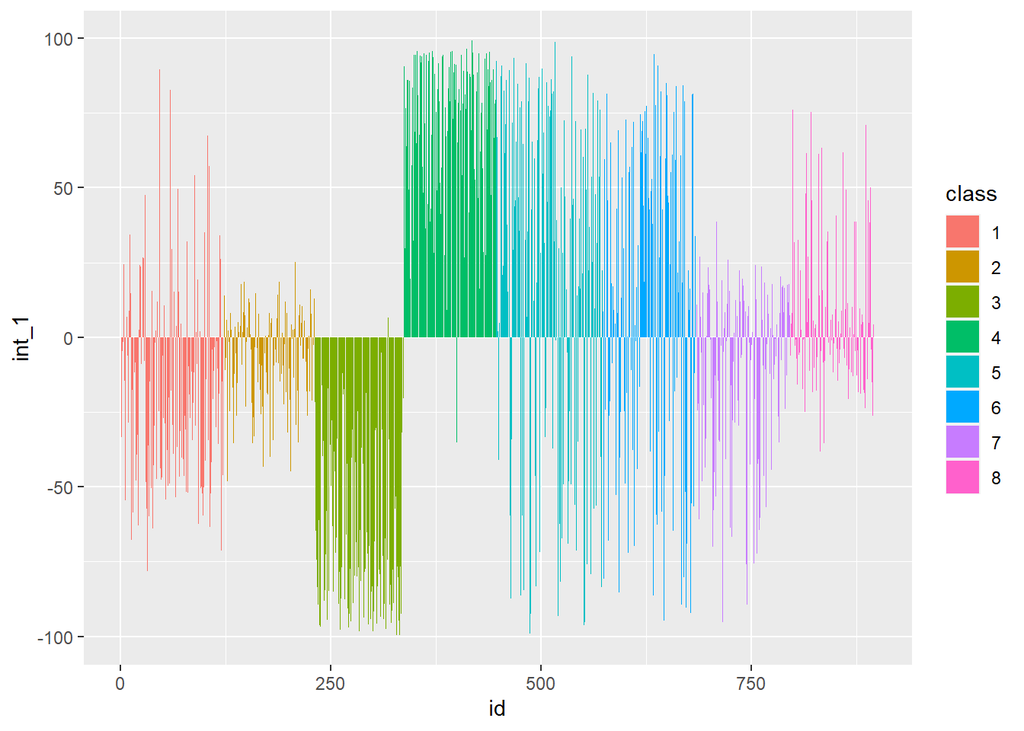

```r
ggplot(data=interval_stats, aes(x=id, y=int_1,fill=class)) +
  geom_bar(stat="identity")
```

```r
stats=whole_data[,list(mean=mean(valueY),median=median(valueY),stdev=sd(valueY)),by=list(class,id,interval_id)]
head(stats)
```

```
##    class id interval_id      mean     median    stdev
## 1:     1  1           1 -90.19521 -104.89124 34.47736
## 2:     1  1           2 -51.52143  -45.64968 34.85398
## 3:     1  2           1 -95.01503 -115.41929 35.22206
## 4:     1  2           2 -70.24685  -77.46351 39.34276
## 5:     1  3           1 -85.56596 -102.35736 42.05541
## 6:     1  3           2 -52.50100  -42.99235 32.00728
```

```r
interval_stats=dcast(stats,id+class~paste0('int_',interval_id),value.var='mean')
head(interval_stats)
```

```
##    id class     int_1     int_2
## 1:  1     1 -90.19521 -51.52143
## 2:  2     1 -95.01503 -70.24685
## 3:  3     1 -85.56596 -52.50100
## 4:  4     1 -73.34874 -43.52066
## 5:  5     1 -60.14555 -74.21639
## 6:  6     1 -92.28293 -76.27481
```

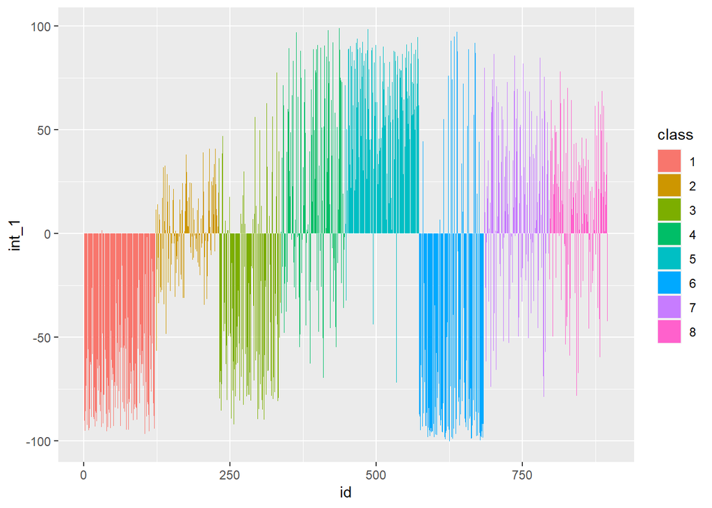

```r
ggplot(data=interval_stats, aes(x=id, y=int_1,fill=class)) +
  geom_bar(stat="identity")
```

On the other hand boxplot representations are also good for the identifying classes. They are located at different locations.